# Big Brother Barometer

Rishabh Verma

11 March, 2021

# Abstract

My phone has a gyroscope and a barometer, which respectively measure rotational velocity and air pressure. This paper centers around the phenomenon that when I touch the screen, the barometer registers a spike in air pressure, likely because the force of my finger causes a volume deflection inside the phone. The gyroscope is susceptible to recording tremors in the hand holding the phone, but if the barometer can indicate WHEN touch input occurs, the gyroscope can indicate WHERE on the screen the touch input occurs. This could be applied to create a malicious background process which can read a user’s PIN code with access only to barometer and gyroscope sensor data. This report is a work in progress.

# Presenting the data

```r
tidbits <- read_csv("data/data.csv")
```

I’ve made an Android app that, when I hit “start” and “stop”, it captures the following data:

Type 1: accelerometer data (includes x/y/z)  
Type 4: gyroscope data (includes x/y/z)  
Type 6: pressure data  
Type -27: touch data

The numbers 1,4,6 come from the [Android Sensor API](https://developer.android.com/reference/android/hardware/Sensor#constants). I picked the number -27 myself.

A tidbit is an event which includes the fields `type, time, one, two, three`. The latter three fields include the sensor reading/event information corresponding to the type.

- For the accelerometer data and the gyroscope data, one/two/three corresponds to x/y/z.
- For the pressure data, one corresponds to the reading and two/three are null.
- For the touch data, one/two correspond to x/y location on the screen, and three is null.

Now let’s talk about why the touch data needs to be calibrated.

# Cleaning the data

Each data tidbit is timestamped, but **sensor events and touch events use different clocks**. The Android API bases touch timestamps off of the “uptimeMillis” clock and bases sensor timestamps off of the “elapsedRealtimeNanos” clock. These are different time-counting systems, and so I have to convert them. I want to keep the sensor data as accurate as possible, and the touch data only needs to be approximate, so I choose to convert the touch data to match the elapsedRealtimeNanos clock.

You can see the difference in timestamp-system here. I have to remove some of the leading sig figs because the difference occurs in less-significant digits and would otherwise be truncated by R’s output.

```r
accelerometer %>% select(time) %>% mutate(time = time %% 1e+12) %>% summary()
```

```
##       time
##  Min.   :3.452e+11
##  1st Qu.:3.562e+11
##  Median :3.672e+11
##  Mean   :3.672e+11
##  3rd Qu.:3.783e+11
##  Max.   :3.893e+11
```

```r
gyroscope %>% select(time) %>% mutate(time = time %% 1e+12) %>% summary()
```

```
##       time
##  Min.   :3.452e+11
##  1st Qu.:3.562e+11
##  Median :3.672e+11
##  Mean   :3.672e+11
##  3rd Qu.:3.783e+11
##  Max.   :3.893e+11
```

```r
pressure %>% select(time) %>% mutate(time = time %% 1e+12) %>% summary()
```

```
##       time
##  Min.   :3.452e+11
##  1st Qu.:3.562e+11
##  Median :3.673e+11
##  Mean   :3.673e+11
##  3rd Qu.:3.783e+11
##  Max.   :3.893e+11
```

```r
uncalibrated_touch %>% select(time) %>% mutate(time = time %% 1e+11) %>% summary()
```

```
##       time
##  Min.   :120622862
##  1st Qu.:120629937
##  Median :120642021
##  Mean   :120642850
##  3rd Qu.:120654616
##  Max.   :120664846
```

To perform the conversion, my app also records two data points at the start and at the stop.

Type -1: uptimeMillis at start and at stop, for touch events (2 data points) Type -2: elapsedRealtimeNanos at start and at stop, for sensor events (2 data points)

```r
uptimeMillisStart <- tidbits %>%
  filter(type == -1) %>%
  select(time) %>%
  slice(1) %>%
  as.double()

uptimeMillisEnd <- tidbits %>%
  filter(type == -1) %>%
  select(time) %>%
  slice(2) %>%
  as.double()

elapsedRealtimeNanosStart <- tidbits %>%
  filter(type == -2) %>%
  select(time) %>%
  slice(1) %>%
  as.double()

elapsedRealtimeNanosEnd <- tidbits %>%
  filter(type == -2) %>%
  select(time) %>%
  slice(2) %>%
  as.double()
```

To convert from millis to nanos, the equation is `y = mx+b` where `y` is in nanos, `x` is in millis, `m` is the slope between them (should expect 10^6) and `b` is the y-intercept.

We can confirm the slope using the secant between the start and end points.

```r
m = (elapsedRealtimeNanosEnd - elapsedRealtimeNanosStart) / (uptimeMillisEnd - uptimeMillisStart)
(m - 1e+6)/1e+6*100 # percent error from 10^6
```

```
## [1] -0.0001536057
```

The above percent-error is very close to zero.

Then for a point
$$(x_1,y_1)$$
, I can calculate
$$b = y_1 - mx_1$$
. Then we can convert all of the time data for the touch input

```r
b = elapsedRealtimeNanosEnd - m*uptimeMillisEnd

touch <- uncalibrated_touch %>%
  mutate(time = m*time + b)

touch %>% select(time) %>% mutate(time = time %% 1e+12) %>% summary()
```

```
##       time
##  Min.   :3.466e+11
##  1st Qu.:3.537e+11
##  Median :3.658e+11
##  Mean   :3.666e+11
##  3rd Qu.:3.784e+11
##  Max.   :3.886e+11
```

That looks better!

# Examining the data: Can this really work?

Now we’re going to graph this data. Let 0 and 1 represent the beginning and the end of the touch input. I want a function such that, if I want to graph the middle 50% of the data, I can call the function with parameters start=0.25, end=0.75, and it graphs the proportion of data between those two points.

I have three global variables: the time of `first_touch` and `last_touch`, which correspond to 0 and 1. Their difference is stored in `range`.

I have a function `trim(data, start, end)` which requires as input the data and the proportions to select. It uses the global variables above: `first_touch`, `last_touch`, `range`. It returns the selection of sensor data which matches the time proportion.

I also have a function `scatterplot(data, value, start, end)` which inputs data, the column to display, and the proportions to select. It will `trim()` the data and graph the specified column with timestamps corresponding to touch input overlaid as vertical bars.

So what does the data look like? Let’s look at the gyroscope sensors and the pressure sensor. **Orange vertical lines represent the occurrence of touch input.**

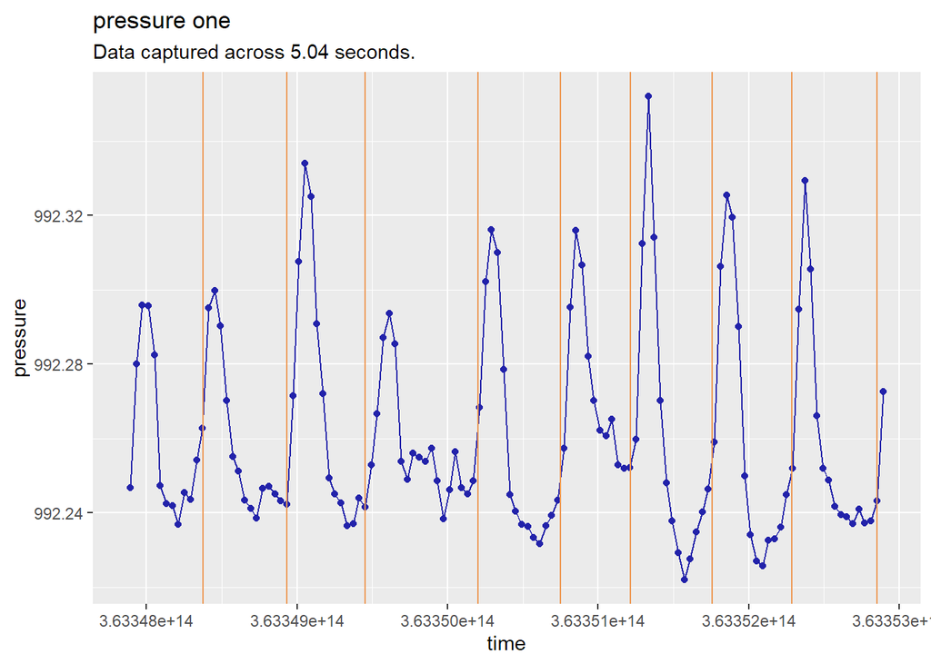

```r
scatterplot(pressure, "one", 0.03, 0.15)
```

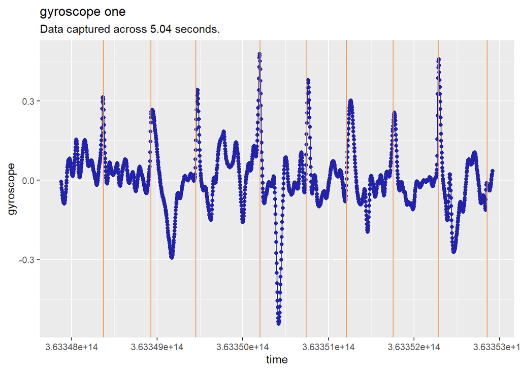

```r
scatterplot(gyroscope, "one", 0.03, 0.15)
```

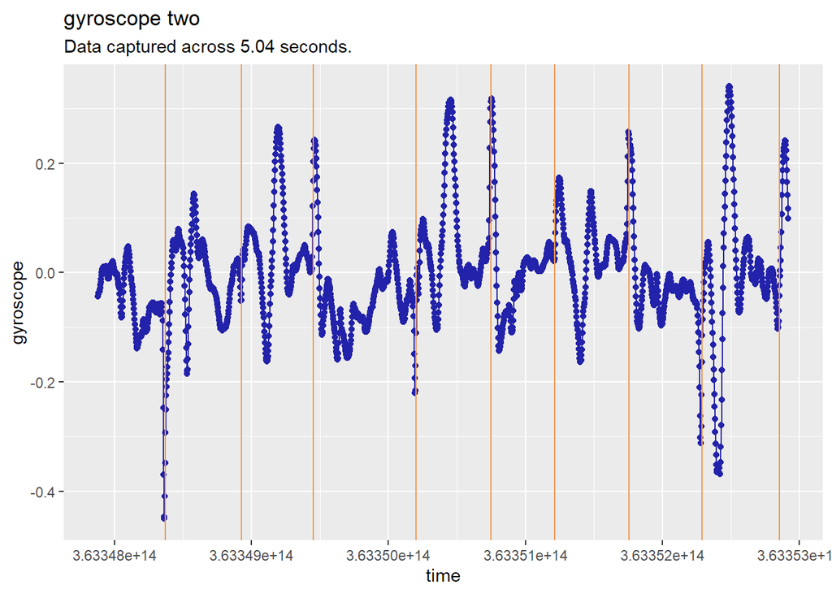

```r
scatterplot(gyroscope, "two", 0.03, 0.15)
```

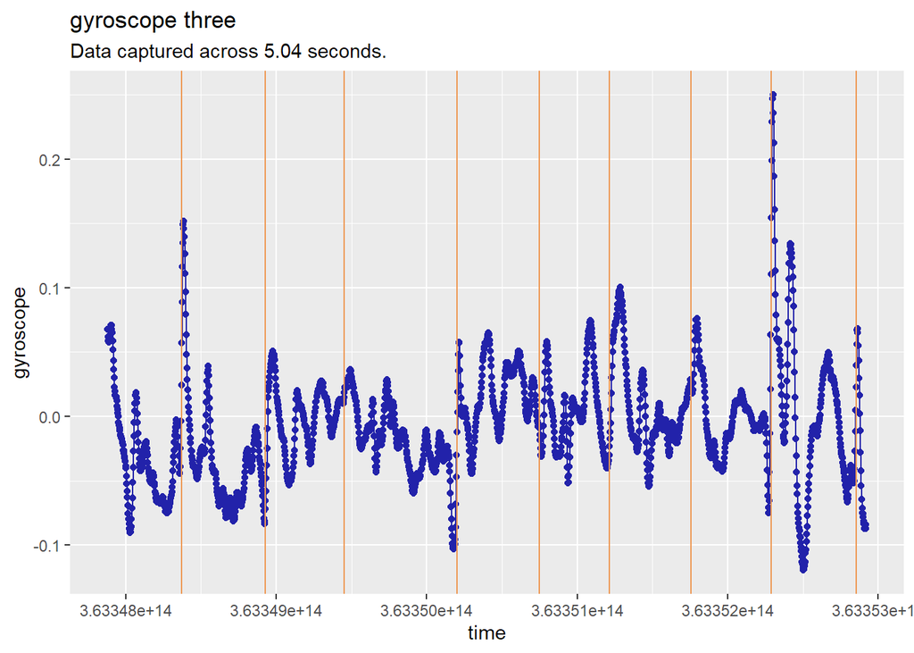

```r
scatterplot(gyroscope, "three", 0.03, 0.15)
```

Each touch input is accompanied by a spike in the gyroscope data. The direction of this spike on the three axes may be indicative of which way the device rotates while the user taps the screen, which we MIGHT be able to use to determine touch location. The problem with this data is that there are some gyroscope spikes which don’t match the touch data as the user shifts the phone in their hand between taps.

The pressure data provides us with a way around this. There is a strong one-to-one relation between pressure spikes and touch events. A touch event occurs just before a pressure spike. This makes sense when your finger pushes a button, the touchscreen detects your finger before your finger makes firm contact with the screen.

So let’s start by using peaks in the pressure data to identify the occurrence of touch input.